author: 3032247297

```r
library(readr)
library(caTools)
df <- read_csv("C:/Users/Murtz.Kizilbash/Desktop/ieor142/hw2/framingham.csv")
set.seed(123)



sample = sample.split(df$male, SplitRatio = .7)
train = subset(df, sample == TRUE)
test = subset(df, sample == FALSE)
```

```r
model <- glm(TenYearCHD~ glucose + heartRate + BMI + diaBP +sysBP + totChol + diabetes + prevalentHyp + prevalentStroke + BPMeds + cigsPerDay + currentSmoker + age + education + male, data = train)

summary(model)
```

```
##
## Call:
## glm(formula = TenYearCHD ~ glucose + heartRate + BMI + diaBP +
##     sysBP + totChol + diabetes + prevalentHyp + prevalentStroke +
##     BPMeds + cigsPerDay + currentSmoker + age + education + male,
##     data = train)
##
## Deviance Residuals:
##      Min        1Q    Median        3Q       Max
## -0.70155  -0.18441  -0.10427  -0.01103   1.10208
##
## Coefficients:
##                                           Estimate Std. Error t value
## (Intercept)                             -6.399e-01  9.348e-02  -6.846
## glucose                                  9.817e-04  3.838e-04   2.558
## heartRate                               -3.124e-04  5.818e-04  -0.537
## BMI                                      1.911e-03  1.832e-03   1.043
## diaBP                                   -2.158e-03  9.806e-04  -2.201
## sysBP                                    3.462e-03  5.901e-04   5.867
## totChol                                  7.501e-05  1.604e-04   0.468
## diabetes                                 2.686e-02  5.204e-02   0.516
## prevalentHyp                             6.274e-03  2.077e-02   0.302
## prevalentStroke                          7.060e-02  9.130e-02   0.773
## BPMeds                                   1.889e-02  4.241e-02   0.445
## cigsPerDay                               2.126e-03  9.208e-04   2.309
## currentSmoker                            2.200e-02  2.164e-02   1.017
## age                                      6.581e-03  9.233e-04   7.127
## educationHigh school/GED                -9.063e-03  2.374e-02  -0.382
## educationSome college/vocational school -4.464e-03  2.635e-02  -0.169
## educationSome high school                1.376e-02  2.311e-02   0.595
## male                                     5.491e-02  1.485e-02   3.697
##                                         Pr(>|t|)
## (Intercept)                             9.49e-12 ***
## glucose                                 0.010591 *
## heartRate                               0.591336
## BMI                                     0.297195
## diaBP                                   0.027821 *
## sysBP                                   5.02e-09 ***
## totChol                                 0.640008
## diabetes                                0.605791
## prevalentHyp                            0.762611
## prevalentStroke                         0.439435
## BPMeds                                  0.656060
## cigsPerDay                              0.021030 *
## currentSmoker                           0.309456
## age                                     1.33e-12 ***
## educationHigh school/GED                0.702712
## educationSome college/vocational school 0.865498
## educationSome high school               0.551607
## male                                    0.000223 ***
## ---
## Signif. codes:  0 '***' 0.001 '**' 0.01 '*' 0.05 '.' 0.1 ' ' 1
##
## (Dispersion parameter for gaussian family taken to be 0.1146586)
##
##     Null deviance: 325.00  on 2559  degrees of freedom
## Residual deviance: 291.46  on 2542  degrees of freedom
## AIC: 1740.5
##
## Number of Fisher Scoring iterations: 2
```

$$560000(p/4) + 60000(1-p/4) = 500000(p)$$

$p = .16$

```r
test$prediction = predict(model, newdata = test, type = 'response')

high_risk <- subset(test, prediction >= .16)
low_risk <- subset(test, prediction < .16)

tp = nrow(subset(test, prediction >= .16 & TenYearCHD == 1))
fn = nrow(subset(test, prediction < .16 & TenYearCHD == 1))
fp = nrow(subset(test, prediction >= .16 & TenYearCHD == 0))
tn = nrow(subset(test, prediction < .16 & TenYearCHD == 0))

tpr = tp/(tp + fn)
fpr = fp/(fp+tn)
accuracy = (tp+tn)/(tp+fp+fn+tn)

tpr
```

```
## [1] 0.68
```

```r
fpr
```

```
## [1] 0.3770314
```

```r
accuracy
```

```
## [1] 0.6320583
```

the true positive rate is .68 the false positive rate is .377 the accuracy is .63

The tpr tells us the number of people who contracted CHD in 10 years that were correctly identified.

The fpr tells us the proportion of negative cases incorrectly identified by the model

the accuracy tells us the proportion of the data that was correctly identified.

This assumption does not make much sense because if taking medecine does not have an affect on the development of the condition, then the premise of this study is invalid.

if taking preventative medicines does reduce the outcome of CHD:

```r
predTest = predict(model, test, type = 'response')
table(test$TenYearCHD, predTest > .999)
```

```
##
##     FALSE
##   0   923
##   1   175
```

```r
new <- data.frame(male=0, age=51, education = 'College', currentSmoker=1, cigsPerDay = 20, BPMeds = 0, prevalentStroke = 0, prevalentHyp = 1, diabetes = 0, totChol = 220, sysBP = 140, diaBP = 100, BMI = 31, heartRate = 59, glucose = 78)

predict(model, newdata = new, type = 'response')
```

```
##         1
## 0.1692132
```

the predicted probability that this patient will contract CHD in the next 10 years is .17, we should prescribe the medecine bc the patent probabiity exceeds the threshold.

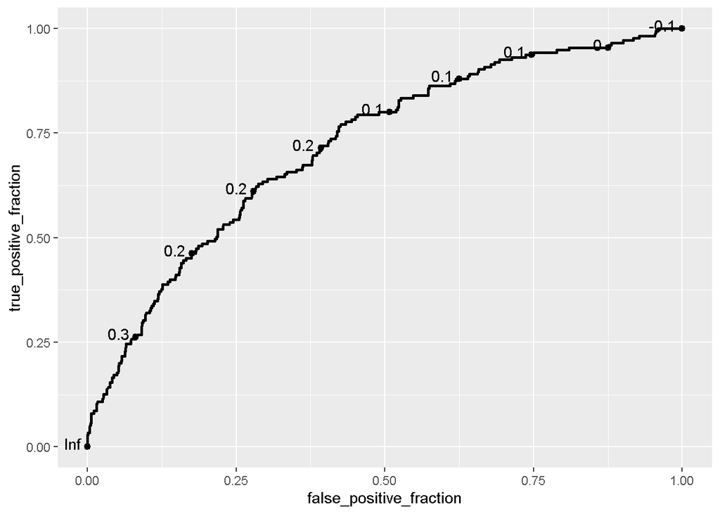

```r
library(plotROC)
ggplot(test, aes(d = test$TenYearCHD, m = test$prediction)) + geom_roc()
```

the ROC curve looks at the tradeoff between fpr and tpr. We want a high tpr and low fpr, if we decrease the threshold to allow for more positive predictions, the classifier will have a higher fpr as we classify more predictions as yes. The ROC curve looks almost like a step function that increases and plateaus at intervals.

AUC = .739

4. There are many issues with this study and this analysis, prescribing a medication when we do not even know if it will have a preventitive affect is both alarming and could introduce some horrible side effects. One way to fix this is to run a small case study or do some analysis that would allow us to holistically look at the sorts of things going on